# SPY_negative_skewness

```python
from IPython.display import HTML
```

```python
HTML('''<script>
code_show=true;
function code_toggle() {
 if (code_show){
 $('div.input').hide();
 } else {
 $('div.input').show();
 }
 code_show = !code_show
}
$( document ).ready(code_toggle);
</script>
The raw code for this IPython notebook is by default hidden for easier reading.
To toggle on/off the raw code, click <a href="javascript:code_toggle()">here</a>.''')
```

The raw code for this IPython notebook is by default hidden for easier reading. To toggle on/off the raw code, click here.

| [*Home*](https://antonio-catalano.github.io/) | [*About*](https://antonio-catalano.github.io/about.html) | [*Archive*](https://antonio-catalano.github.io/Archive.html) |  |
| --- | --- | --- | --- |

# The negative skewness of SPY ETF returns

### We analize the growth of 1000$ invested in the SPY ETF between 1993 (inception) and January 2020.

### The annualized compound total return from the inception of the ETF to January 2020 is about 9,5%.

### In our analysis we used the log returns to exploit the additive property, but the conclusion would be the same.

#### What would have been the growth if we had excluded the best days and the worst days from our trading strategy?

**We took the data from the yahoo finance database.**  
**We have replaced the missed worst days and the missed best days with a return equal to 0.**

```python
import matplotlib.pyplot as plt
import numpy as np, pandas as pd
import warnings
warnings.filterwarnings('ignore')
import seaborn as sns
plt.style.use('bmh')
from scipy.stats import skew
```

```python
df1 = pd.read_csv('SPY.csv')
df1.set_index('Date', inplace = True)
df1.index = pd.to_datetime(df1.index)
```

```python
df = df1.copy()
```

```python
log_rets = (np.log(df['Adj Close']) - np.log(df['Adj Close'].shift(1)))[1:]
```

```python
length_period = len(df.resample('Y')) - 1

cagr = ((df['Adj Close'][-1] - df['Adj Close'][0]) / df['Adj Close'][0])**(1/length_period) - 1
```

```python
three_moments = pd.DataFrame([np.mean(log_rets), np.std(log_rets), skew(log_rets)], index = ['Mean', 'Std', 'Skewness']\
                , columns = ['1993-2020 SPY daily returns stats'])
```

```python
pd.DataFrame(dict(CAGR = cagr), index = ['1993-2020'])
```

|  | CAGR |
| --- | --- |
| 1993-2020 | 0.094844 |

```python
three_moments
```

|  | 1993-2020 SPY daily returns stats |
| --- | --- |
| Mean | 0.000372 |
| Std | 0.011412 |
| Skewness | -0.146467 |

The effects of the negative skewness can be further investigated by wondering:  
1) What would our final capital have been if we had excluded the top $n$ worst days?  
2) What would our final capital have been if we had excluded the top $n$ best days?

```python
def growth_without_worstdays(df1):
    wealths = []
    total_log_ret = np.sum(df1)
    final_wealth = np.exp(total_log_ret)*1000
    print('Growth of 1000$ from 1993 to 2020: {}$'.format((np.exp(total_log_ret)*1000).round(2)))
    print()
    df = df1.copy()
    wealths.append(final_wealth)
    missed_worst_days = [1,5,15,25]
    xticks_ = ['Top ' + str(i) for i in [1,5,15,25]]
    for n in missed_worst_days:
        values_to_convert_in_zero = df.sort_values().values[:n]
        log_rets_minus_n_worstdays = df.where(df > values_to_convert_in_zero.max(),0.)
        total_log_ret = np.sum(log_rets_minus_n_worstdays)
        final_wealth = np.exp(total_log_ret)*1000
        wealths.append(final_wealth)
        print('Growth of 1000$ without {} top worst days: {}$'.format(n, final_wealth.round(2)))
        print()
    fig, ax = plt.subplots(figsize=(10,8))
    xpos = [i+1 for i,_ in enumerate(missed_worst_days)]
    sns.barplot([0]+xpos, wealths, ax = ax)
    for i,t in zip(ax.patches,wealths):
    # get_x pulls left or right; get_height pushes up or down
        ax.text(i.get_x()+.2, i.get_height()+10, \
                str(int(t))+' $', fontsize=15,
                    color='yellow', backgroundcolor = 'black' )
    plt.xticks([0]+xpos, ['Total period'] + xticks_, fontsize = 'large')
    plt.xlabel('Missed worst days', fontsize = 'xx-large')
    plt.ylabel('Growth of 1000$', fontsize = 'xx-large')
    plt.title('Performance of SPY 1993-2020 ',fontsize = 'x-large',color = 'yellow',backgroundcolor = 'black')
    return None
```

### Let's start excluding the worst days of the SPY

```
Growth of 1000$ from 1993 to 2020: 12548.23$

Growth of 1000$ without 1 top worst days: 13918.47$

Growth of 1000$ without 5 top worst days: 19296.72$

Growth of 1000$ without 15 top worst days: 35586.79$

Growth of 1000$ without 25 top worst days: 57406.0$
```

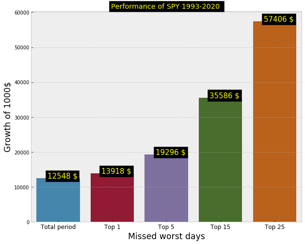

```python
growth_without_worstdays(log_rets)
```

```python
def growth_without_bestdays(df1):
    wealths = []
    total_log_ret = np.sum(df1)
    final_wealth = np.exp(total_log_ret)*1000
    print('Growth of 1000$ from 1993 to 2020 {}$'.format((np.exp(total_log_ret)*1000).round(2)))
    print()
    df = df1.copy()
    wealths.append(final_wealth)
    missed_best_days = [1,5,15,25]
    xticks_ = ['Top ' + str(i) for i in [1,5,15,25]]
    for n in missed_best_days:
        values_to_convert_in_zero = df.sort_values(ascending = False).values[:n]
        log_rets_plus_n_bestdays = df.where(df < values_to_convert_in_zero.min(),0.)
        total_log_ret = np.sum(log_rets_plus_n_bestdays)
        final_wealth = np.exp(total_log_ret)*1000
        wealths.append(final_wealth)
        print('Growth of 1000$ without {} best days: {}$'.format(n, final_wealth.round(2)))
        print()
    fig, ax = plt.subplots(figsize=(10,8))
    xpos = [i+1 for i,_ in enumerate(missed_best_days)]
    sns.barplot([0]+xpos, wealths, ax = ax)
    for i,t in zip(ax.patches,wealths):
    # get_x pulls left or right; get_height pushes up or down
        ax.text(i.get_x()+.2, i.get_height()+10, \
                str(int(t))+' $', fontsize=15,
                    color='yellow', backgroundcolor = 'black' )
    plt.xticks([0]+xpos, ['Total period'] + xticks_, fontsize = 'large')
    plt.xlabel('Missed best days', fontsize = 'xx-large')
    plt.ylabel('Growth of 1000$', fontsize = 'xx-large')
    plt.title('Performance of SPY, 1993-2020 ',fontsize = 'x-large', color = 'yellow',backgroundcolor = 'black')
    return None
```

### Now we exclude the best days of the S&P 500 Index

```
Growth of 1000$ from 1993 to 2020 12548.23$

Growth of 1000$ without 1 best days: 10957.26$

Growth of 1000$ without 5 best days: 8057.87$

Growth of 1000$ without 15 best days: 4691.84$

Growth of 1000$ without 25 best days: 2991.48$
```

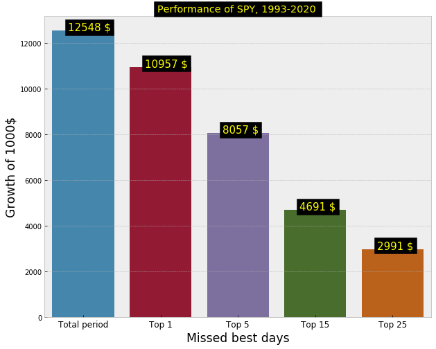

```python
growth_without_bestdays(log_rets)
```

Let's suppose that we have a risk-neutral prototype investor under a single bet scenario.  
In other words, under a single gamble scenario, such investor is indifferent to risk to lose \$100 in order to win \$100 if the probability is the same (0.5).

And let's suppose that we have the following gamble: with probability 0.5 our investor will obtain the final capital without the top worst $n$ days or with the same probability he will obtain the final capital without the top best $n$ days.

The graphs above show that our prototype investor would refuse the gamble for $n$ equal to 1.  
Indeed $12548$ (the final capital without the gamble) $> 0.5 \times 10957 + 0.5 \times 13918$.  
But for $n$ >1 our investor will take the gamble because the gain he would obtain if he missed the $n$ worst days would exceed the money he would lose if he missed the $n$ best days (and this fact is increasingly evident as $n$ increases).  
This is a natural consequence of the negative skewness of historical daily returns of the S&P 500 index.